# Topic 5

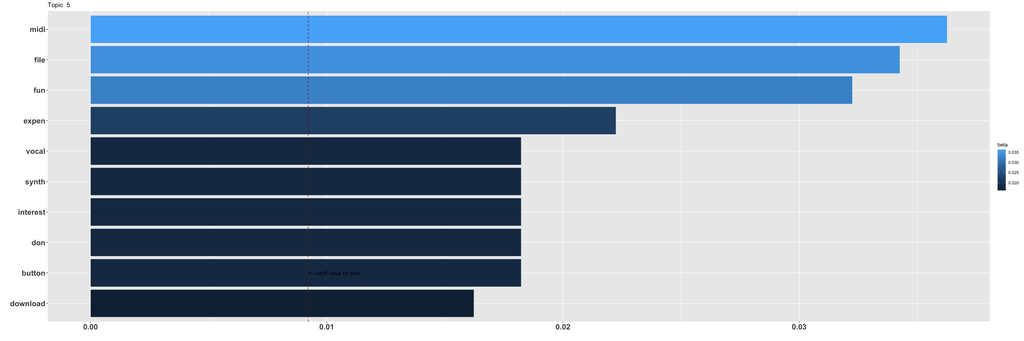

On interpreting beta: the term has a beta probability of being generated from the particular topic.

Values below are gamma : An estimated proportion of words from that document that are generated from that topic.

**Text Record Number: 1219** gamma: 44 % likelihood of this document (based on its words) in this topic

**I believe this website to be a great resource for anyone interested in pop music and improvisation: https://remixpacks.ru/

In this website you can find any popular song from the last 20 or 50 years. It has downloads for each song and each download will give you 5+ wav files. One wav file will be just the kickdrum track, one wav file will be just the guitar/chords. one wav file for the piano maybe. one wav file for the vocals. one for the FX. one for synths. a wav file for backing vocals.

If you’re interested in pop music and improvisation what you can do is have the vocal track play. Or maybe have both the vocal track and the backing vocal track play simultaneously. or even have the drums playing too.

and you can improvise at the piano while it plays. why not learn from the pop masters? or just try it for a bit of fun. You will need a DAW to get multiple files playing simultaneously, or at least something like audacity to merge the audio files you want playing for when you want to improvise.

I find this is really a great way to learn the (are you actually learning anything?) melodic/harmonic/chord structures of pop songs. You find out what key the song is in. Start the vocal playing, and figure out your own instrumental for the song. Have the song repeat maybe 3 or 4 times probably and your playing gets pretty alright.

I believe there are also machine learning algorithms (free and good quality ones) that can separate drums from vocals from synths from guitar from piano when given a wav file of any song. You can look into this; for songs that are more rarefied and not available on remixpacks. Haven’t tried this myself.

Improvising over pop songs is a lot of good fun - whether or not you separate vocals or not**

**Text Record Number: 960** gamma: 44 % likelihood of this document (based on its words) in this topic

**For music production, a standalone MIDI keyboard works perfectly fine. What you get with the more expensive MIDI keyboards is tons of extra bells and whistles, specifically geared towards music production. Some of the more expensive ones have their own built in synthesizers and a massive selection of patches to choose from, so you don’t need to use them with a DAW and can instead sample the banks directly or capture live audio playback from the keyboard and use that in your music production.

The other bells and whistles you get are control features that you can bind to various things within whatever DAW you’re using. On cheap MIDI keyboards, at a bare minimum you will most likely get a pitch bend and mod wheel. These are probably the most commonly used features that any synth loaded into a DAW will take advantage of, so having these is important. But the more expensive MIDI keyboards take it a step further and typically have dozens of other buttons and knobs that you can map to individual functions of whatever synth you’re using.

For example instead of having to open the synth on your computer and click around for presets, you could just map some buttons on your MIDI keyboard to change presets for you. Or you could map specific functions within that synth, such as attack/decay/etc to knobs, or put control for LFO envelopes on knobs as well. Basically, the more expensive ones with all these controls are meant to be mapped out by you, based on your own needs for whatever synths you’re using in software.

For being primarily used as a tool for music production, a basic keyboard with at least a pitch bend and mod wheel will cover your needs fairly well. I would only recommend getting something more expensive if you think you actually need all the control a more expensive one provides. You can always just alter the synths in your DAW software by using a mouse and keyboard, but some people really prefer the convenience of just having some knobs and buttons on their instrument to do this on the fly.**